# BTL_XSTK

Group_8

2024-10-07

**1.TIỀN XỬ LÝ SỐ LIỆU**

1.1 Đọc dữ liệu (Import data):

Đầu tiên, chúng ta đọc dữ liệu từ tệp tin All_GPUs.csv và in hiển thị một vài dòng đầu tiên. Việc này giúp chúng ta có cái nhìn tổng quan về dữ liệu, hiểu cấu trúc, định hướng trước khi đi sâu vào phân tích dữ liệu. Quá trình này được mô tả trong hình dưới đây:

```r
All_GPUs <- read.csv("All_GPUs.csv")
head(All_GPUs, 6)
```

```
##   Architecture Best_Resolution Boost_Clock Core_Speed DVI_Connection Dedicated
## 1  Tesla G92b                                 738 MHz              2       Yes
## 2     R600 XT       1366 x 768                   \n-               2       Yes
## 3    R600 PRO       1366 x 768                   \n-               2       Yes
## 4       RV630       1024 x 768                   \n-               2       Yes
## 5       RV630       1024 x 768                   \n-               2       Yes
## 6       RV630       1024 x 768                   \n-               2       Yes
##   Direct_X DisplayPort_Connection HDMI_Connection Integrated L2_Cache
## 1  DX 10.0                     NA               0         No      0KB
## 2    DX 10                     NA               0         No      0KB
## 3    DX 10                     NA               0         No      0KB
## 4    DX 10                     NA               0         No      0KB
## 5    DX 10                     NA               0         No      0KB
## 6    DX 10                     NA               0         No      0KB
##   Manufacturer Max_Power   Memory Memory_Bandwidth Memory_Bus Memory_Speed
```

[output cut: 34 more lines]

1.2. Kiểm tra và xử lý dữ liệu khuyết trong tập dữ liệu:

Ta sẽ thực hiện thống kê số lượng và tỷ lệ dữ liệu khuyết ở các biến, từ đó xử lý lựa chọn ra các biến chính để phân tích. Tuy nhiên, ta nhận thấy rằng các giá trị khuyết không cùng loại. Nó có thể là giá trị trống (hay rỗng) , gạch ngang “-” ,.. gây khó khăn cho việc thống kê dữ liệu khuyết . Vì thế, để thuận tiện ta chuyển đổi tất cả chúng thành giá trị NA.  
Đầu tiên, tìm các dòng trống (hàng có toàn bộ các giá trị là rỗng hoặc ““) trong dữ liệu và chuyển chúng thành giá trị NA:

```r
# Thay thế tất cả các ô trống trong dữ liệu All_GPUs bằng NA
All_GPUs[All_GPUs == ""] <- NA
```

Tiếp đó, tìm các giá trị trong dataframe có định dạng -(các giá trị bắt đầu bằng ký tự xuống dòng theo sau là dấu - ) và chuyển chúng thành NA. Ta sử dụnglệnh gsub() để thay thế “-” bằng NA trong toàn bộ dataframe.

```r
# Thay thế các giá trị có định dạng "\n-" bằng NA trong tất cả các cột của All_GPUs
All_GPUs[] <- lapply(All_GPUs, function(x) gsub("^\\n- $", NA, x))
```

Cuối cùng là thay thế các chuỗi “NA” (N/A) thành NA.

```r
All_GPUs[All_GPUs == "NA"] <- NA
```

Bây giờ các dữ liệu khuyết đã đồng nhất, ta tiến hành thống kê số lượng và tỷ lệ dữ liệu khuyết ở các biến bằng hàm **freq.na()** trong thư viện **questionr**.

```r
# Sử dụng hàm freq.na() để tìm tần suất NA trong dữ liệu
na_summary <- freq.na(All_GPUs)
# Chuyển kết quả thành một data frame
na_summary_df <- as.data.frame(na_summary)
colnames(na_summary_df) <- c("NA_Count", "NA_Percentage")
kable(na_summary_df, format = "markdown", caption = "Số lượng và tỉ lệ dữ liệu khuyết ở các biến")
```

Số lượng và tỉ lệ dữ liệu khuyết ở các biến

|  | NA_Count | NA_Percentage |
| --- | --- | --- |
| Release_Price | 2850 | 84 |
| DisplayPort_Connection | 2549 | 75 |
| Boost_Clock | 1960 | 58 |
| PSU | 1175 | 34 |
| Core_Speed | 907 | 27 |
| HDMI_Connection | 763 | 22 |
| VGA_Connection | 758 | 22 |
| DVI_Connection | 750 | 22 |
| Power_Connector | 709 | 21 |
| Best_Resolution | 642 | 19 |
| Max_Power | 625 | 18 |
| Pixel_Rate | 544 | 16 |
| Texture_Rate | 544 | 16 |
| ROPs | 538 | 16 |
| TMUs | 538 | 16 |
| Process | 463 | 14 |
| Memory | 420 | 12 |
| Resolution_WxH | 195 | 6 |
| Memory_Bandwidth | 121 | 4 |
| Shader | 107 | 3 |
| Memory_Speed | 105 | 3 |
| Architecture | 62 | 2 |
| Memory_Bus | 62 | 2 |
| Memory_Type | 56 | 2 |
| Open_GL | 40 | 1 |
| Dedicated | 14 | 0 |
| Integrated | 14 | 0 |
| Direct_X | 6 | 0 |
| L2_Cache | 0 | 0 |
| Manufacturer | 0 | 0 |
| Name | 0 | 0 |
| Notebook_GPU | 0 | 0 |
| Release_Date | 0 | 0 |
| SLI_Crossfire | 0 | 0 |

Dựa trên kết quả thu được ở trên, ta nhận thấy có nhiều biến chứa dữ liệu khuyết, để dễ dàng hơn, ta thực hiện vẽ đồ thị thể hiện tỷ lệ dữ liệu khuyết ở từng biến bằng cách sử dụng hàm **ggplot2**. Ta thu được đồ thị như hình dưới đây.

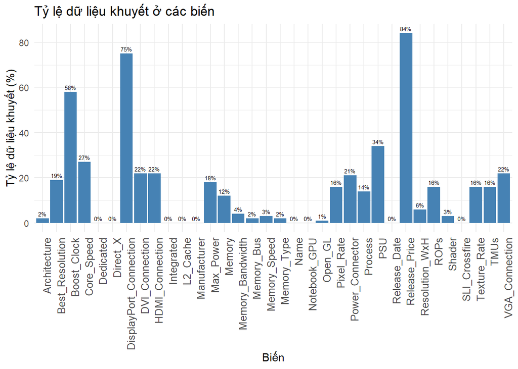

Với các biến có tỷ lệ dữ liệu khuyết lơn hơn 15% ta sẽ xóa đi để giảm nhiễu cho quá trình phân tích. Và đồng thời với các biến có tỷ lệ dữ liệu khuyết dưới 15%, ta sẽ xóa đi các quan sát chứa dữ liệu khuyết, với 3406 quan sát việc này vẫn đảm báo không làm mất đi tính chính xác và tầm quan trọng của biến.

```r
# Giữ lại các biến có tỷ lệ dữ liệu khuyết dưới 15%
selected_cols <- rownames(na_summary_df)[na_summary_df$NA_Percentage < 15]

# Giữ lại các biến thỏa mãn điều kiện trong dataframe ban đầu
new_All_GPUs <- All_GPUs[, selected_cols]

#Xoá các quan sát chứa dữ liệu khuyết
new_All_GPUs<-na.omit(new_All_GPUs)
```

1.3. Lựa chọn biến:  
Sau khi đã loại bỏ đi các biến có tỷ lệ khuyết cao, ta sẽ chọn lọc các biến quan trọng. Qua tìm hiểu, nhóm nhận thấy biến **Memory_Speed** là một nhân tố quan trọng ảnh hướng đến hiệu suất của GPU. Tốc độ xung nhịp bộ nhớ là một yếu tố thiết yếu trong hiệu suất của GPU, đặc biệt đối với các tác vụ yêu cầu GPU truy cập nhiều dữ liệu. Tốc độ xung nhịp bộ nhớ cao hơn có nghĩa là GPU có thể truy cập bộ nhớ nhanh hơn, dẫn đến tăng hiệu suất.  
**Memory_Speed** không chỉ là về tốc độ xung nhịp, nó có liên quan và chịu ảnh hưởng trực tiếp bởi **Memory_Bandwidth**.  
Và các nhân tố khác có ảnh hưởng với mức độ khác nhau đến **Memory_Speed** bao gồm: “Memory_Type”,“Memory_Bus”,“L2_Cache”,“Architecture”,“Process”,“Memory”,“Dedicated”.  
Ta có thể lấy thêm biến “Manufacturer”để so sánh và nhận xét về **Memory_Speed** của các GPU ở các nhà sản xuất khác nhau.

Đây là một số nguồn tài liệu và cơ sở ta có thể tham khảo để tìm hiểu về các biến có ảnh hưởng đến *Memory_Speed* trong GPU.

Link: https://vibox.co.uk/blog/gpu-memory-clock-speed-vs-gpu-core-clock-speed  
Link: https://www.hp.com/us-en/shop/tech-takes/does-ram-speed-matter

1.4. Làm sạch dữ liệu:  
1.4.1 Xử lý đơn vị Để thuận tiện hơn cho quá trình phân tích, ta sẽ bỏ đi đơn vị của các biến như “L2_Cache”, “Memory”,“Memory_Bandwidth”,“Memory_Bus”, “Memory_speed”, “Process”. Việc này giúp đồng nhất dữ liệu, hợp lý hóa phân tích về sau giúp việc so sánh và diễn giải dữ liệu trên các biến trở nên đơn giản hơn.

```r
# Lựa chọn các biến cần xoá đơn vị
columns_to_clean <- c("L2_Cache","Memory","Memory_Bandwidth","Memory_Bus","Memory_Speed","Process")

#Tạo hàm thực hiện xoá đơn vị ở các biến
remove_units <- function(column) {
  # Sử dụng gsub để xóa tất cả các ký tự không phải số (kể cả đơn vị)
  cleaned_column <- gsub("[^0-9.]", "", column)
  # Chuyển đổi kết quả về kiểu numeric
  cleaned_column <- as.numeric(cleaned_column)

  return(cleaned_column)
}

# Áp dụng hàm cho các biến đã chọn
new_All_GPUs[columns_to_clean] <- lapply(new_All_GPUs[columns_to_clean], remove_units)
```

Cuối cùng, kiểm tra lại số lượng giá trị bị khuyết để xác nhận rằng đây thực sự là tập dữ liệu cuối cùng sau khi làm sạch. Như minh họa trong hình dưới , không còn dữ liệu khuyết trong tập dữ liệu cuối cùng. Như vậy quá trình làm sạch dữ liệu đã thành công.

```
##                  missing %
## Process                0 0
## Memory                 0 0
## Resolution_WxH         0 0
## Memory_Bandwidth       0 0
## Shader                 0 0
## Memory_Speed           0 0
## Architecture           0 0
## Memory_Bus             0 0
## Memory_Type            0 0
## Open_GL                0 0
## Dedicated              0 0
## Integrated             0 0
## Direct_X               0 0
## L2_Cache               0 0
## Manufacturer           0 0
## Name                   0 0
## Notebook_GPU           0 0
## Release_Date           0 0
## SLI_Crossfire          0 0
```

Kết quả của quá trình tiền xử lý số liệu, ta thu được bộ dữ liệu mới gồm các biến chính sẵn sàng cho quá trình phân tích phía sau. Bộ dữ liệu mới được mô tả một số dòng như hình dưới đây:

```r
GPU_data<-new_All_GPUs[c("Memory_Speed","Memory","Memory_Bandwidth","Memory_Type","Memory_Bus","L2_Cache","Architecture","Process","Dedicated","Manufacturer")]
head(GPU_data)
```

```
##   Memory_Speed Memory Memory_Bandwidth Memory_Type Memory_Bus L2_Cache
## 1         1000   1024             64.0       GDDR3        256        0
## 2          828    512            106.0       GDDR3        512        0
## 3          800    512             51.2       GDDR3        256        0
## 4         1150    256             36.8       GDDR4        128        0
## 5          700    256             22.4       GDDR3        128        0
## 6         1100    256             35.2       GDDR4        128        0
##   Architecture Process Dedicated Manufacturer
## 1  Tesla G92b       55       Yes       Nvidia
## 2     R600 XT       80       Yes          AMD
## 3    R600 PRO       80       Yes          AMD
## 4       RV630       65       Yes          AMD
## 5       RV630       65       Yes          AMD
## 6       RV630       65       Yes          AMD
```

**2.THỐNG KÊ MÔ TẢ**

**2.1. Tóm tắt dữ liệu đã được làm sạch**

Để thực hiện tính các thống kê mô tả cho các biến định lượng, nhóm báo cáo sử dụng các hàm có sẵn trong R để tính trung bình, độ lệch chuẩn mẫu, các phân vị, trung vị, giá trị lớn nhất và giá trị nhỏ nhất. Sử dụng tập dữ liệu GPU_data để tính thống kê cho từng cột định lượng. Cách thực hiện như dưới đây:

```r
# Xác định các biến số và tạo một khung dữ liệu chỉ chứa các biến số
new_numeric_vars <- sapply(GPU_data, is.numeric)
numeric_data <- GPU_data[, new_numeric_vars]

# Tính toán các thống kê mô tả cho các biến số
summary_stats <- sapply(numeric_data, function(x) {
  c(
    Mean = mean(x),                   # Trung bình
    SD = sd(x),                       # Độ lệch chuẩn
    Min = min(x),                     # Giá trị nhỏ nhất
    Q1 = quantile(x, 0.25),           # Phân vị 25%
    Median = median(x),               # Trung vị
    Q3 = quantile(x, 0.75),           # Phân vị 75%
    Max = max(x)                      # Giá trị lớn nhất
  )
})

# Chuyển thống kê mô tả thành dataframe và xuất ra dưới dạng bảng
t(as.data.frame(summary_stats))
```

```
##                        Mean         SD Min Q1.25% Median Q3.75%   Max
## Memory_Speed     1280.09594  396.83295 275    950 1251.0 1553.0  2127
## Memory           3140.95108 2829.52970 128   1024 2048.0 4096.0 32000
## Memory_Bandwidth  162.36572  136.52718   4     64  130.6  224.4  1280
## Memory_Bus        221.58210  234.99052  32    128  192.0  256.0  4096
## L2_Cache         1482.62799 3408.42555   0    256  512.0 1024.0 30722
## Process            32.02958   13.80621  14     28   28.0   40.0   150
```

Đối với các biến định tính, nhóm lập bảng thống kê số lượng cho các phân loại.

```r
# Thống kê số lượng cho biến Memory_Type
table(GPU_data$Memory_Type)
```

```
##
##    DDR   DDR2   DDR3  eDRAM  GDDR2  GDDR3  GDDR4  GDDR5 GDDR5X  HBM-1  HBM-2
##      7     40    359      2      3    177      4   1956     78      6      5
```

```r
# Thống kê số lượng cho biến Dedicated
table(GPU_data$Dedicated)
```

```
##
##   No  Yes
##    3 2634
```

```r
# Thống kê số lượng cho biến Manufacturer
table(GPU_data$Manufacturer)
```

```
##
##    AMD    ATI  Intel Nvidia
##   1004     82      3   1548
```

**2.2. Vẽ đồ thị histogram cho biến Memory_Speed bằng đồ thị ggplot**

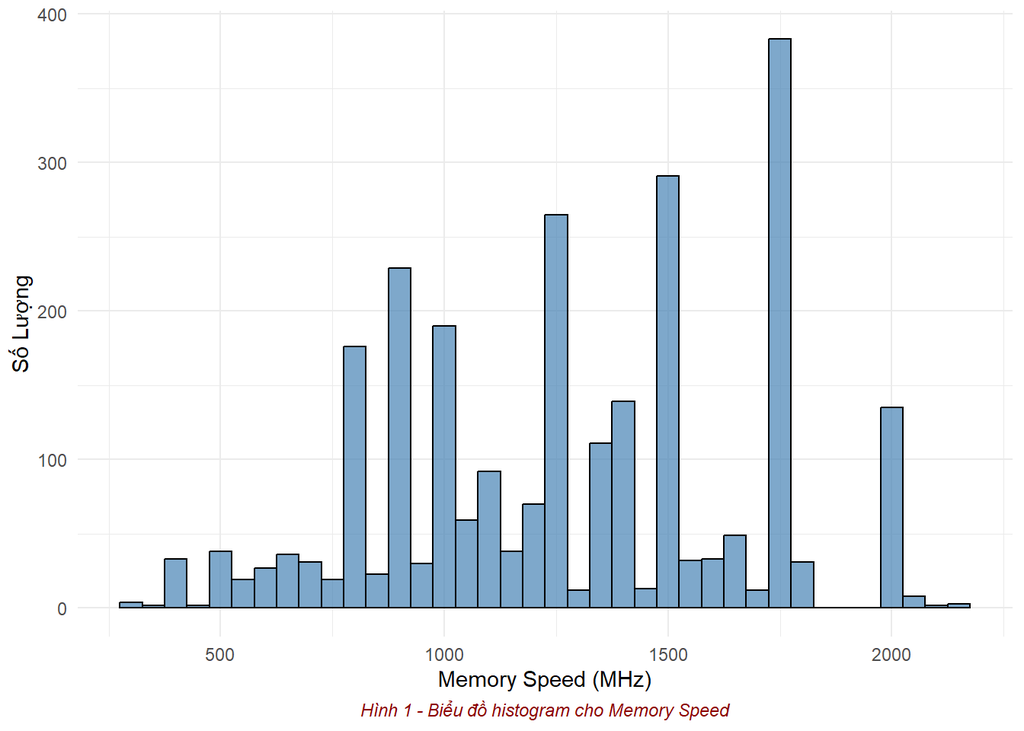

```r
# Vẽ histogram cho biến Memory_Speed với binwidth tùy chỉnh
ggplot(GPU_data, aes(x = Memory_Speed)) +
  geom_histogram(binwidth = 50, fill = "steelblue", color = "black", alpha = 0.7) +
  labs(x = "Memory Speed (MHz)",  # Ghi chú đơn vị nếu cần
       y = "Số Lượng",
       caption = paste("Hình 1 - Biểu đồ histogram cho Memory Speed")) +
  theme_minimal()+
      theme(
        plot.caption = element_text(hjust = 0.5, face = "italic", color = "darkred")
      )
```

Ở hai đầu của phân phối, các giá trị dưới 500 MHz và trên 2000 MHz xuất hiện rất ít, biểu thị đây là các trường hợp hiếm. Điều này có thể liên quan đến các GPU cũ có hiệu năng thấp hoặc các GPU cao cấp dành cho những ứng dụng đặc thù.

Phân phối không đồng đều này cho thấy sự đa dạng về hiệu năng của các GPU trong tập dữ liệu. Tuy nhiên, sự tập trung mạnh ở một số khoảng giá trị gợi ý rằng một vài dòng sản phẩm chiếm ưu thế lớn trên thị trường. Để hiểu rõ hơn về các đặc điểm chi tiết, việc điều chỉnh binwidth hoặc phân tích các thông số kỹ thuật tương ứng có thể hữu ích. Ngoài ra, cần kiểm tra các giá trị bất thường ở hai đầu phân phối để loại bỏ khả năng dữ liệu lỗi hoặc ngoại lệ không hợp lý.

**2.3. Vẽ đồ thị boxplot cho biến Memory_Speed theo Manufacturer, Dedicated, MemoryType.**

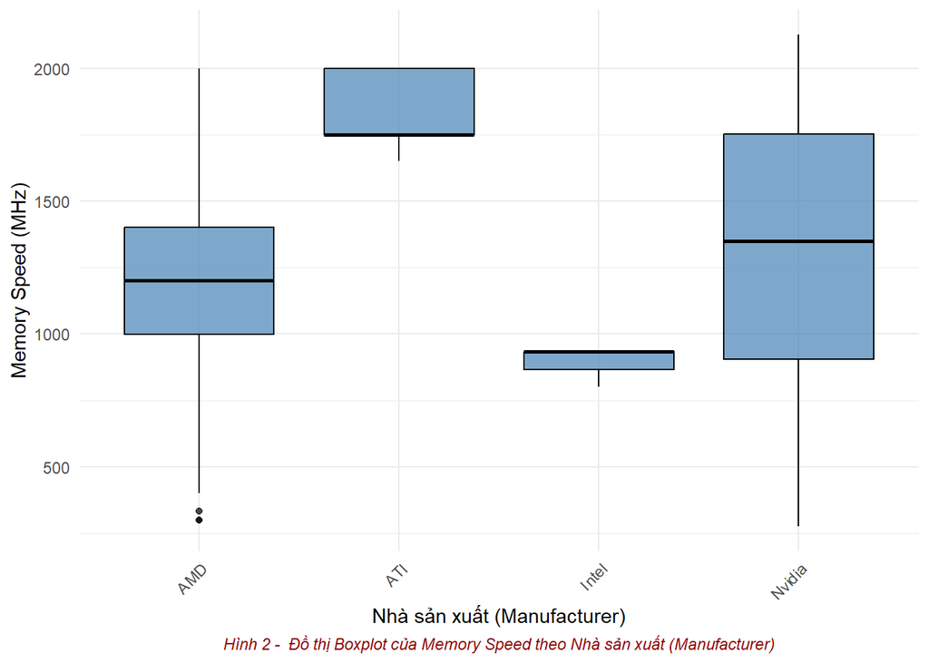

```r
# Vẽ boxplot cho Memory_Bandwidth theo Manufacturer
ggplot(GPU_data, aes(x = Manufacturer, y = Memory_Speed)) +
  geom_boxplot(fill = "steelblue", color = "black", alpha = 0.7) +  # Thay đổi màu sắc và độ trong suốt của hộp
  labs(
       x = "Nhà sản xuất (Manufacturer)",
       y = "Memory Speed (MHz)",
       caption = paste("Hình 2 -  Đồ thị Boxplot của Memory Speed theo Nhà sản xuất (Manufacturer)")) +
  theme_minimal() +
  theme(axis.text.x = element_text(angle = 45, hjust = 1),
        plot.caption = element_text(hjust = 0.5, face = "italic", color = "darkred")
        )  # Xoay nhãn trục x để dễ đọc hơn
```

Dựa trên đồ thị, nhóm rút ra một số nhận xét về sự phân bố Memory Speed của GPU được phân loại theo nhà sản xuất, bao gồm AMD, ATI, Intel, và Nvidia: Các nhà sản xuất như AMD và Nvidia có phạm vi phân bố rộng, thể hiện danh mục sản phẩm đa dạng từ tầm thấp đến cao cấp. ATI tập trung vào các sản phẩm cao cấp với Memory Speed vượt trội. Intel có phân khúc rõ ràng ở nhóm hiệu năng thấp, phù hợp với GPU tích hợp.

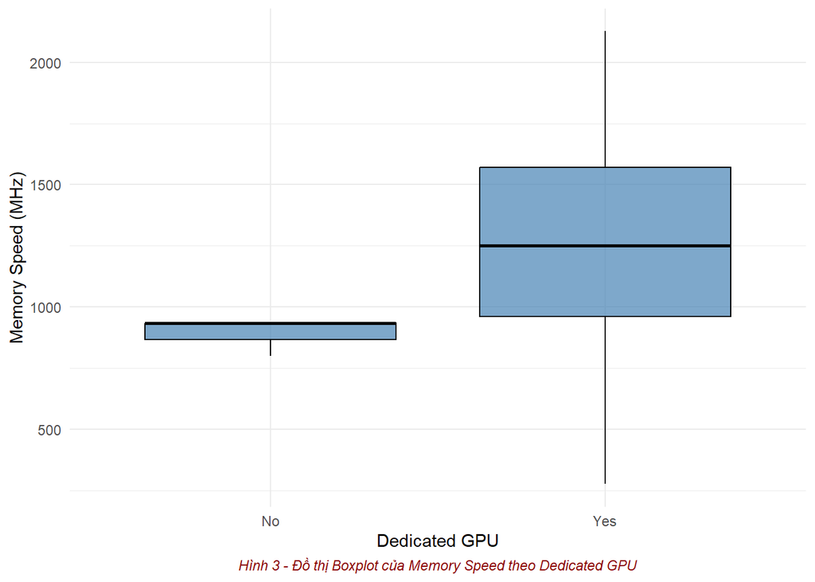

```r
# Vẽ boxplot cho Memory_Bandwidth theo Dedicated
ggplot(GPU_data, aes(x = Dedicated, y = Memory_Speed)) +
  geom_boxplot(fill = "steelblue", color = "black", alpha = 0.7) +  # Thay đổi màu sắc và độ trong suốt của hộp
  labs(
       x = "Dedicated GPU",
       y = "Memory Speed (MHz)",
        caption = paste( "Hình 3 - Đồ thị Boxplot của Memory Speed theo Dedicated GPU")) +
  theme_minimal() +
  theme(axis.text.x = element_text(angle = 0, hjust = 0.5),
        plot.caption = element_text(hjust = 0.5, face = "italic", color = "darkred")
        )  # Điều chỉnh vị trí nhãn trục x
```

Nhóm rút ra một số nhận xét về đồ thị boxplot “Memory Speed theo Dedicated GPU”:

Non-Dedicated GPU (No): Phân bố Memory Speed của nhóm này rất hẹp, với giá trị chủ yếu nằm trong khoảng 1000 MHz. Điều này cho thấy GPU tích hợp có tốc độ bộ nhớ thấp và đồng nhất hơn, phù hợp với vai trò hỗ trợ cơ bản thay vì xử lý đồ họa chuyên sâu.

GPU rời (Dedicated GPU) có tốc độ bộ nhớ cao hơn đáng kể so với GPU tích hợp, phù hợp với các nhu cầu xử lý đồ họa phức tạp và chuyên nghiệp. GPU tích hợp (Non-Dedicated GPU) có hiệu năng thấp hơn và ít biến động, phù hợp với các ứng dụng cơ bản như văn phòng, xem phim, hoặc chơi game nhẹ.

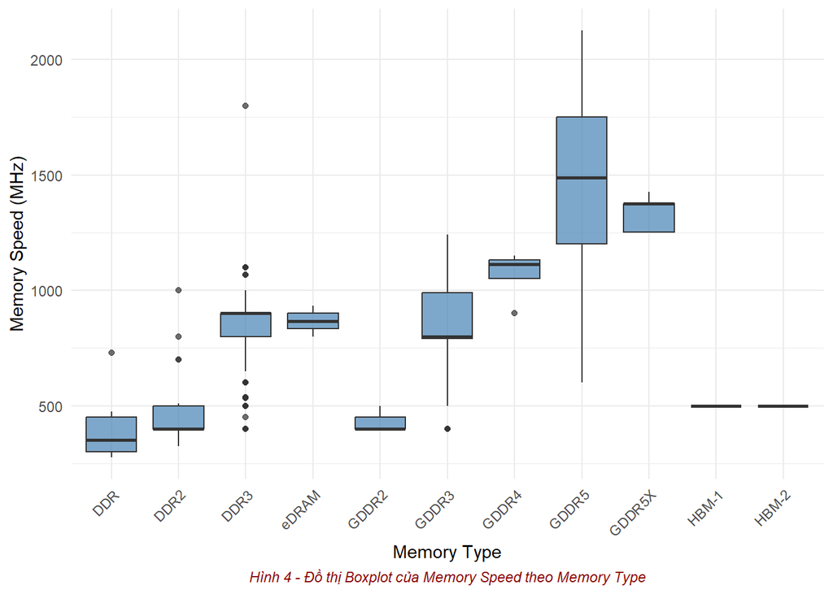

```r
# Vẽ boxplot cho Memory_Bandwidth theo Shader
ggplot(GPU_data, aes(x = Memory_Type, y = Memory_Speed)) +
  geom_boxplot(fill = "steelblue", alpha = 0.7) +  # Thay đổi màu sắc và độ trong suốt
  labs(
       x = "Memory Type",
       y = "Memory Speed (MHz)",
       caption = "Hình 4 - Đồ thị Boxplot của Memory Speed theo Memory Type") +
  theme_minimal() +
  theme(axis.text.x = element_text(angle = 45, hjust = 1), plot.caption = element_text(hjust = 0.5, face = "italic", color = "darkred")
        )  # Xoay nhãn trục x
```

Dựa trên biểu đồ boxplot về Memory Speed (MHz) theo Memory Type, nhóm rút ra các nhận xét sau:

Công nghệ bộ nhớ đã có sự cải tiến đáng kể theo thời gian, với tốc độ ngày càng cao ở các thế hệ mới. GDDR5 và GDDR5X hiện tại có ưu thế lớn về hiệu suất. Tuy nhiên, đặc điểm của từng loại bộ nhớ còn phụ thuộc vào mục tiêu sử dụng (băng thông, hiệu suất, hay tiết kiệm năng lượng).

**2.4. Vẽ biểu đồ tương quan giữa các biến:**

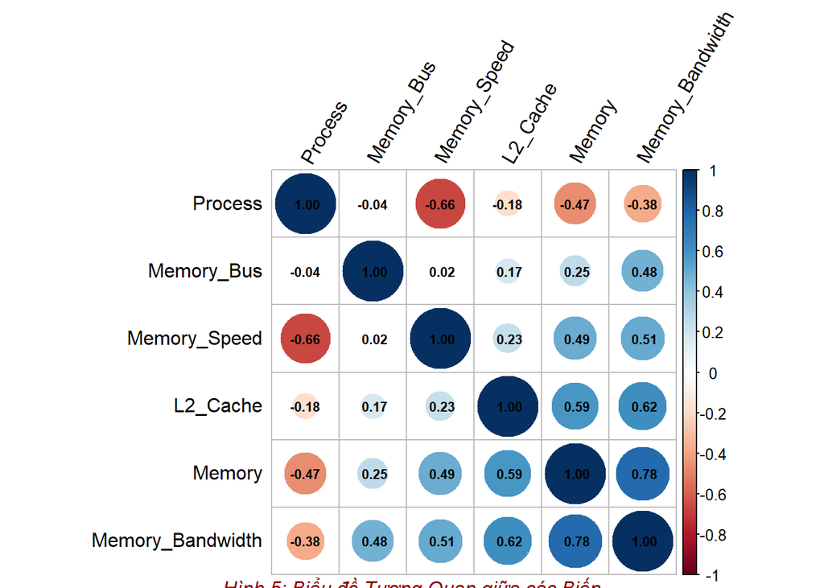

```r
# Tính ma trận tương quan
cor_matrix <- cor(GPU_data[, sapply(GPU_data, is.numeric)], use = "complete.obs")
# Vẽ biểu đồ tương quan
p <- corrplot(cor_matrix, method = "circle", type = "full", order = "hclust",
              addCoef.col = "black", tl.col = "black", tl.srt = 60,
              number.cex = 0.7, mar = c(0,0,0.5,0))

# Thêm tiêu đề dưới biểu đồ
grid.text("Hình 5: Biểu đồ Tương Quan giữa các Biến",
          x = 0.5,  # Căn giữa theo chiều ngang
          y = 0.001,  # Điều chỉnh vị trí chiều dọc, âm để xuống dưới
          gp = gpar(fontsize = 12, fontface = "italic", col = "darkred"))
```

Dựa trên kết quả từ ma trận tương quan, ta có thể đưa ra nhận xét về mối quan hệ giữa Memory_Speed và các biến khác:

Memory_Speed và Memory: Có mối tương quan dương trung bình với tương quan = 0.49. Điều này cho thấy rằng tốc độ bộ nhớ có sự phụ thuộc đáng kể vào dung lượng bộ nhớ. Điều này có nghĩa là khi dung lượng bộ nhớ tăng lên, tốc độ bộ nhớ cũng có thể tăng, và sự thay đổi này có thể được phản ánh trong các mô hình học máy hoặc phân tích dữ liệu.

Memory_Speed và Memory_Bandwidth: Mối quan hệ giữa băng thông bộ nhớ và tốc độ bộ nhớ là rất quan trọng, vì tốc độ bộ nhớ và băng thông có liên quan mật thiết trong việc xử lý dữ liệu. Memory_Bandwidth có thể là yếu tố quan trọng ảnh hưởng đến Memory_Speed.

Memory_Speed và Memory_Bus: Có mối tương quan rất yếu với tương quan = 0.02. Điều này cho thấy rằng độ rộng bus bộ nhớ không có ảnh hưởng đáng kể đến tốc độ bộ nhớ.

Memory_Speed và L2_Cache: L2_Cache có thể ảnh hưởng đến tốc độ bộ nhớ, nhưng mối quan hệ này phụ thuộc vào nhiều yếu tố khác như kiến trúc và quy trình sản xuất. Nếu tương quan yếu hoặc không rõ ràng, có thể chỉ ra rằng bộ nhớ cache không phải yếu tố quyết định chính.

Memory_Speed và Process:Mối quan hệ này có thể là nghịch, đặc biệt nếu quy trình sản xuất (Process) cũ hơn có thể làm giảm tốc độ bộ nhớ.

**2.5.Vẽ đồ thị scatter plot cho biến Memory_Speed theo các biến “Memory_Bandwidth”, “L2_Cache”, “Memory_Bus”, ” Process”, “Memory”.**

Để xác định xu hướng biến đổi cho tốc độ bộ nhớ theo các biến khác ta vẽ đồ thị phân tán:

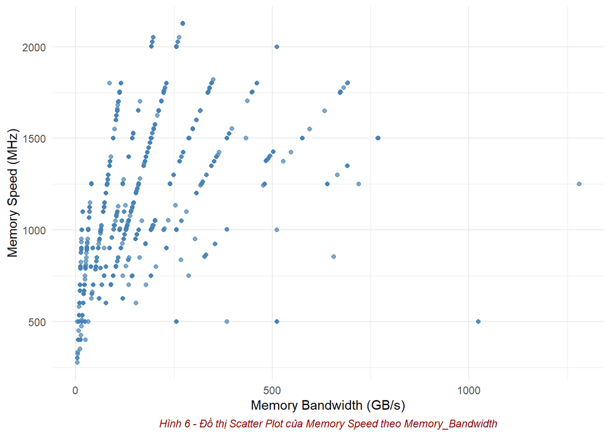

```r
# Vẽ scatter plot cho Memory_Speed theo Memory_Bandwidth
ggplot(GPU_data, aes(x = Memory_Bandwidth, y = Memory_Speed)) +
  geom_point(color = "steelblue", alpha = 0.7) +  # Thay đổi màu sắc và độ trong suốt của điểm
  labs(x = "Memory Bandwidth (GB/s)",
       y = "Memory Speed (MHz)",
       caption = "Hình 6 - Đồ thị Scatter Plot của Memory Speed theo Memory_Bandwidth") +
  theme_minimal()+
      theme(
        plot.caption = element_text(hjust = 0.5, face = "italic", color = "darkred")
      )
```

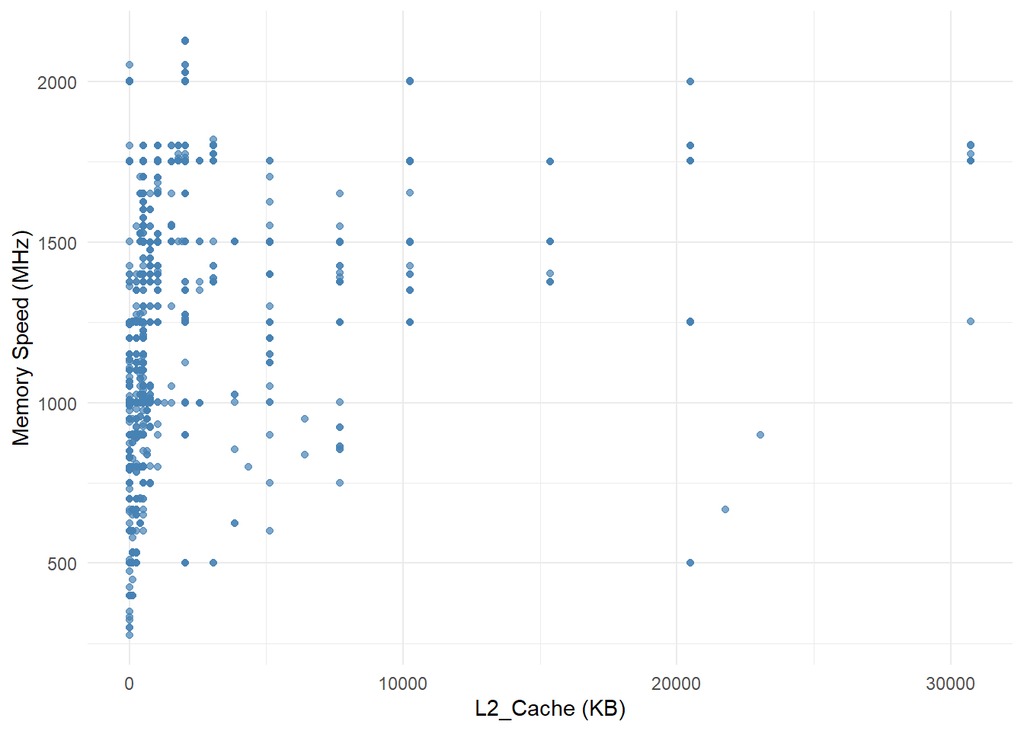

```r
# Vẽ scatter plot cho Memory_Speed theo L2_Cache
ggplot(GPU_data, aes(x = L2_Cache, y = Memory_Speed)) +
  geom_point(color = "steelblue", alpha = 0.7) +  # Thay đổi màu sắc và độ trong suốt của điểm
  labs(
       x = "L2_Cache (KB)",
       y = "Memory Speed (MHz)",
       Caption = "Hình 7 - Đồ thị Scatter Plot của Memory Speed theo L2_Cache") +
  theme_minimal()+
      theme(
        plot.caption = element_text(hjust = 0.5, face = "italic", color = "darkred")
      )
```

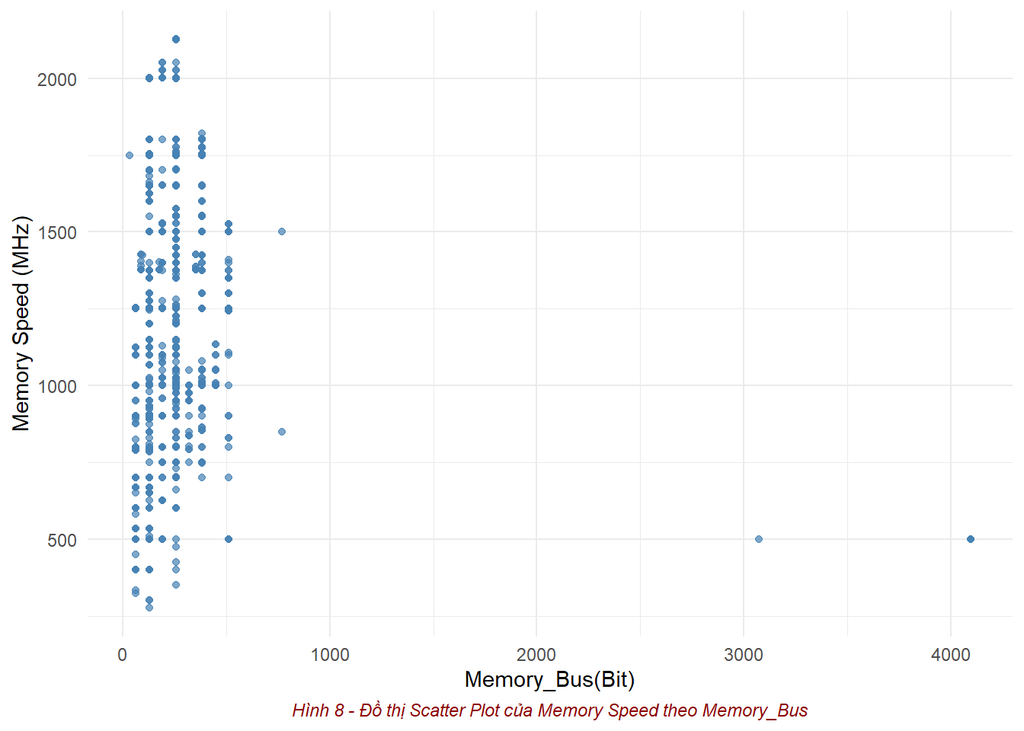

```r
ggplot(GPU_data, aes(x = Memory_Bus, y = Memory_Speed)) +
  geom_point(color = "steelblue", alpha = 0.7) +  # Thay đổi màu sắc và độ trong suốt của điểm
  labs(
       x = "Memory_Bus(Bit)",
       y = "Memory Speed (MHz)",
       caption = "Hình 8 - Đồ thị Scatter Plot của Memory Speed theo Memory_Bus") +
  theme_minimal()+
      theme(
        plot.caption = element_text(hjust = 0.5, face = "italic", color = "darkred")
      )
```

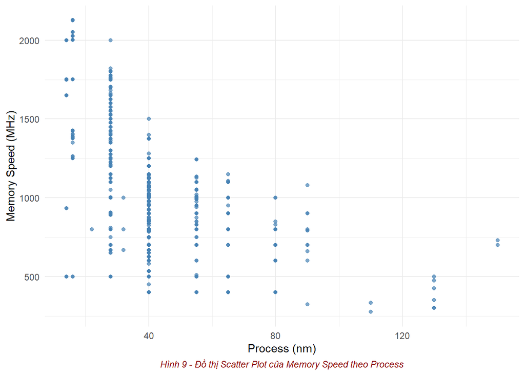

```r
ggplot(GPU_data, aes(x = Process, y = Memory_Speed)) +
  geom_point(color = "steelblue", alpha = 0.7) +  # Thay đổi màu sắc và độ trong suốt của điểm
  labs(
       x = "Process (nm)",
       y = "Memory Speed (MHz)",
       caption = "Hình 9 - Đồ thị Scatter Plot của Memory Speed theo Process" ) +
  theme_minimal()+
      theme(
        plot.caption = element_text(hjust = 0.5, face = "italic", color = "darkred")
      )
```

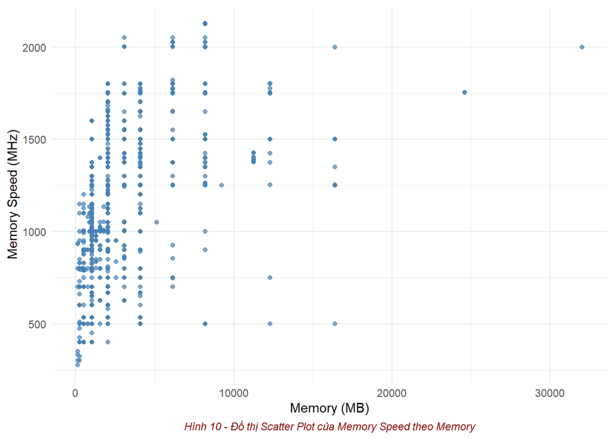

```r
ggplot(GPU_data, aes(x = Memory, y = Memory_Speed)) +
  geom_point(color = "steelblue", alpha = 0.7) +  # Thay đổi màu sắc và độ trong suốt của điểm
  labs(x = "Memory (MB)",
       y = "Memory Speed (MHz)",
       caption = "Hình 10 - Đồ thị Scatter Plot của Memory Speed theo Memory") +
  theme_minimal()+
      theme(
        plot.caption = element_text(hjust = 0.5, face = "italic", color = "darkred")
      )
```

Dựa trên biểu đồ phân tán của biến Memory Speed theo các biến “Memory_Bandwidth”, “L2_Cache”, “Memory_Bus”, “Process”, “Memory”, nhóm rút ra một số nhận xét:

Có một xu hướng chung chỉ ra rằng Memory Bandwidth cao hơn có liên quan đến Memory Speed cao hơn. Điều này có nghĩa là khi băng thông bộ nhớ tăng, tốc độ bộ nhớ cũng có xu hướng tăng.Có thể có một số giá trị ngoại lệ trong dữ liệu mà một số cấu hình bộ nhớ không tuân theo xu hướng chung. Việc xác định những giá trị này có thể cung cấp thông tin chi tiết về các trường hợp cụ thể mà hiệu suất bộ nhớ lệch khỏi chuẩn mực.

Có ít điểm dữ liệu hơn cho kích thước bộ nhớ đệm L2 lớn hơn. Các điểm này phân tán nhiều hơn về tốc độ bộ nhớ, cho thấy khi kích thước bộ nhớ đệm L2 tăng lên, tốc độ bộ nhớ thay đổi rộng hơn. Mặc dù biểu đồ cho thấy sự phân phối chung, nhưng nó không chỉ ra mối tương quan rõ ràng hoặc mạnh giữa kích thước bộ nhớ đệm L2 và tốc độ bộ nhớ. Tuy nhiên, nó cho thấy tồn tại nhiều cấu hình khác nhau với kích thước bộ nhớ đệm và tốc độ bộ nhớ khác nhau.

Mối quan hệ giữa tốc độ bộ nhớ và Bus bộ nhớ: Có một xu hướng chung cho thấy rằng các điểm dữ liệu tập trung ở các giá trị thấp của Memory Bus, tức là dưới 1000 Bits. Điều này cho thấy các hệ thống bộ nhớ có Bus bộ nhớ nhỏ hơn thường được sử dụng nhiều hơn.

Mối quan hệ giữa tốc độ bộ nhớ và kích thước quy trình: Có một xu hướng chung cho thấy rằng khi kích thước quy trình giảm (tức là quá trình sản xuất càng tiên tiến), tốc độ bộ nhớ có xu hướng tăng. Điều này cho thấy các công nghệ sản xuất tiên tiến hơn có thể mang lại hiệu suất bộ nhớ cao hơn. Phân bố dữ liệu: Các điểm dữ liệu phân bố khá đều trên đồ thị, cho thấy sự đa dạng trong kích thước quy trình.

**2.3. Xử lý số liệu kỹ hơn**

```r
processed_cols <-c ("Memory_Speed","Memory","Memory_Bandwidth","Memory_Type","Memory_Bus","L2_Cache","Architecture","Process","Dedicated","Manufacturer")
processed_data <- All_GPUs[, processed_cols, drop = FALSE]

processed_data[columns_to_clean] <- lapply(processed_data[columns_to_clean], remove_units)

head(processed_data, 5)
```

```
##   Memory_Speed Memory Memory_Bandwidth Memory_Type Memory_Bus L2_Cache
## 1         1000   1024             64.0       GDDR3        256        0
## 2          828    512            106.0       GDDR3        512        0
## 3          800    512             51.2       GDDR3        256        0
## 4         1150    256             36.8       GDDR4        128        0
## 5          700    256             22.4       GDDR3        128        0
##   Architecture Process Dedicated Manufacturer
## 1  Tesla G92b       55       Yes       Nvidia
## 2     R600 XT       80       Yes          AMD
## 3    R600 PRO       80       Yes          AMD
## 4       RV630       65       Yes          AMD
## 5       RV630       65       Yes          AMD
```

```r
show_na_result <- function() {
  # Sử dụng hàm freq.na() để tìm tần suất NA trong dữ liệu
  na_summary_processed <- freq.na(processed_data)
  # Chuyển kết quả thành một data frame
  na_summary_processed_df <- as.data.frame(na_summary_processed)
  colnames(na_summary_processed_df) <- c("NA_Count", "NA_Percentage")
  kable(na_summary_processed_df, format = "markdown", caption = "Số lượng và tỉ lệ dữ liệu khuyết ở các biến")
}

show_na_result()
```

Số lượng và tỉ lệ dữ liệu khuyết ở các biến

|  | NA_Count | NA_Percentage |
| --- | --- | --- |
| Process | 463 | 14 |
| Memory | 420 | 12 |
| Memory_Bandwidth | 121 | 4 |
| Memory_Speed | 105 | 3 |
| Memory_Bus | 62 | 2 |
| Architecture | 62 | 2 |
| Memory_Type | 56 | 2 |
| Dedicated | 14 | 0 |
| L2_Cache | 0 | 0 |
| Manufacturer | 0 | 0 |

*2.3.1. Xử lý biến Dedicated*

Khi quan sát dữ liệu ta sẽ thấy sự liên quan giữa Manufacturer và Dedicated vì thế ta sẽ tiến hành vẽ đồ thị tấn suất của 2 biến.

```r
# Bảng tần suất
freq_table <- table(processed_data$Manufacturer, processed_data$Dedicated)
head(freq_table)
```

```
##
##            No  Yes
##   AMD     103 1214
##   ATI       0   85
##   Intel   245    7
##   Nvidia   26 1712
```

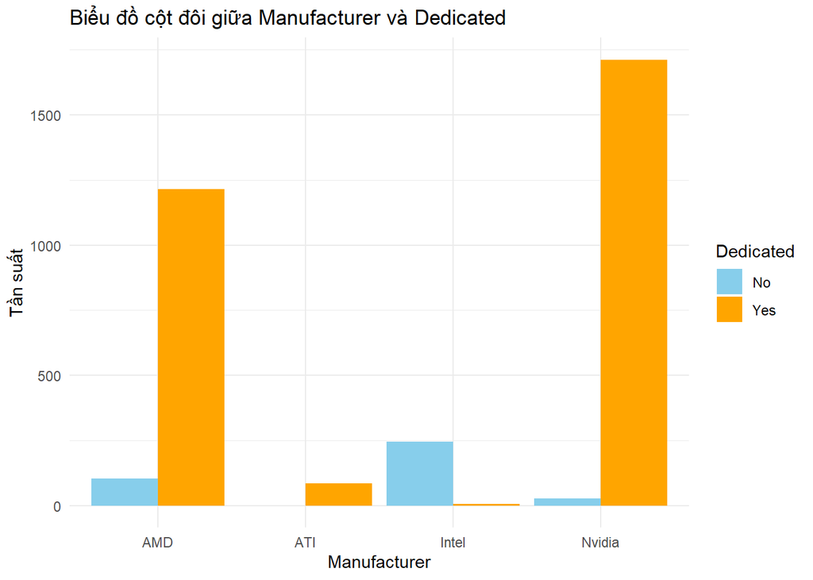

```r
# Biểu đồ
freq_df <- as.data.frame(freq_table)
colnames(freq_df) <- c("Manufacturer", "Dedicated", "Freq")

# Vẽ biểu đồ cột đôi
ggplot(freq_df, aes(x = Manufacturer, y = Freq, fill = Dedicated)) +
  geom_bar(stat = "identity", position = "dodge") +
  labs(title = "Biểu đồ cột đôi giữa Manufacturer và Dedicated",
       x = "Manufacturer",
       y = "Tần suất") +
  scale_fill_manual(values = c("skyblue", "orange")) +
  theme_minimal()
```

Dựa vào biểu đồ trên ta nhận định rằng: - Nếu Manufacturer là AMD, ATI, Nvidia thì Delicated sẽ là Yes - Nếu Manufacturer là Intel thì Delicated sẽ là No Dựa vào nhận định trên ta sẽ tiến hành thay thế các dữ liệu na ở cột Delicated

```r
processed_data$Dedicated[is.na(processed_data$Dedicated) & processed_data$Manufacturer %in% c("AMD", "ATI", "Nvidia")] <- "Yes"
processed_data$Dedicated[is.na(processed_data$Dedicated) & processed_data$Manufacturer == "Intel"] <- "No"
show_na_result()
```

Số lượng và tỉ lệ dữ liệu khuyết ở các biến

|  | NA_Count | NA_Percentage |
| --- | --- | --- |
| Process | 463 | 14 |
| Memory | 420 | 12 |
| Memory_Bandwidth | 121 | 4 |
| Memory_Speed | 105 | 3 |
| Memory_Bus | 62 | 2 |
| Architecture | 62 | 2 |
| Memory_Type | 56 | 2 |
| L2_Cache | 0 | 0 |
| Dedicated | 0 | 0 |
| Manufacturer | 0 | 0 |

*2.3.2. Xử lý biến Memory_Type*

```r
processed_data$Memory_Type <- replace(processed_data$Memory_Type, processed_data$Memory_Type == "DDR" | processed_data$Memory_Type == "DDR2", "DDR1")

processed_data$Memory_Type[is.na(processed_data$Memory_Type) & processed_data$L2_Cache == 0] <- "DDR1"
table(processed_data$Memory_Type)
```

```
##
##   DDR1   DDR3   DDR4  eDRAM  GDDR2  GDDR3  GDDR4  GDDR5 GDDR5X  HBM-1  HBM-2
##    261    657     51      3      5    300      8   2020     79      6      6
```

Ta nhận thấy rằng ngoài các loại có nhiều dữ liệu thì eDRAM, GDDR2, GDDR4, HBM-1 và HBM-2 có rất ít dữ liệu và chỉ còn khoản 10 records là còn na. Từ đây ta sẽ gọp các dữ liệu có ít và dữ liệu na thành một loại dữ liệu mới là Other.

```r
processed_data$Memory_Type <- replace(processed_data$Memory_Type, processed_data$Memory_Type == "eDRAM" | processed_data$Memory_Type == "GDDR2" | processed_data$Memory_Type == "GDDR4" | processed_data$Memory_Type == "HBM-1" | processed_data$Memory_Type == "HBM-2" | is.na(processed_data$Memory_Type), "Other")

table(processed_data$Memory_Type)
```

```
##
##   DDR1   DDR3   DDR4  GDDR3  GDDR5 GDDR5X  Other
##    261    657     51    300   2020     79     38
```

```r
show_na_result()
```

Số lượng và tỉ lệ dữ liệu khuyết ở các biến

|  | NA_Count | NA_Percentage |
| --- | --- | --- |
| Process | 463 | 14 |
| Memory | 420 | 12 |
| Memory_Bandwidth | 121 | 4 |
| Memory_Speed | 105 | 3 |
| Memory_Bus | 62 | 2 |
| Architecture | 62 | 2 |
| Memory_Type | 0 | 0 |
| L2_Cache | 0 | 0 |
| Dedicated | 0 | 0 |
| Manufacturer | 0 | 0 |

*2.3.3. Xử lý biến Architecture*

Ở đây ta nhận thấy tên kiến trúc thường bắt đầu giống nhau và chỉ khác ở hậu tố ví dụ “Kepler GK107” và “Kepler GK104” vì thế ta sẽ tiến hành xóa đi hậu tố chỉ giữ lại tiền tố.

```r
processed_data$Architecture <- sapply(strsplit(processed_data$Architecture, " "), `[`, 1)
table(processed_data$Architecture)
```

```
##
##                  Alviso   Arrandale       Barts         Bay    Bearlake
##           1           1          21           2           1           1
##  Bearlake-B BeaverCreek       Beema   Blackcomb    Braswell  Broadwater
##           2           5           5           1           1           2
##   Broadwell   Brookdale         C51        C51M         C78      Caicos
##          29           1           1           2           1           2
##   Calistoga     Cantiga        Cape      Cayman       Cedar   Clarkdale
##           2           3           1           3           1          11
##     Cypress     D10U-20  Devastator   Eaglelake   Evergreen       Fermi
##           1           1           2           7          16         314
##      G200GL         G70       G70GL        G70M         G71       G71GL
##           1           3           1           2           6           3
##      G71GLM        G71M         G72      G72GLM        G72M         G73
##           3           3           4           3           5           5
##    G73-N-B1        G73M       G80GL         G84       G84GL        G84M
##           1           3           2           4           1          10
##         G86        G86M         G92        G92b        G92M         G94
##           2           6          14           1           6           5
##        G94a        G94b        G94M         G96      G96a/b        G96b
##           1           2           1           8           2           3
##        G96M         G98        G98M         GCN    GF104GLM     GF108GL
##           1           9           2         783           1           1
##    GF108GLM    GF110GLM        GL40      GT200b     GT200GL       GT215
##           1           3           1           1           1           5
##      GT215M       GT216     GT216GL      GT216M       GT218     GT218GL
##           1           4           1           2           3           1
##      GT218M     Haswell    Haswell:     Hemlock         Ivy         Jet
##           3          22           3           3          22           2
##     Juniper      Kabini        Kaby     Kalindi      Kaveri      Kepler
##           3           2           1           7          18         480
##    Lakeport  Lakeport-G    Loveland       M24GL       M56GL         M62
##           1           1           1           1           1           1
##         M64         M66       M66GL       M86GL         M92         M96
##           1           1           1           1           4           4
##       M97GL     Maxwell       MCP51       MCP61      MCP68S      MCP68V
##           1         350           2           3           1           1
##       MCP76       MCP78     MCP79MX     MCP79XT     MCP7A-U  Montara-GM
##           2           3           3           1           1           1
##   NB9P-GLM2        NV10        NV11        NV15        NV16        NV17
```

[output cut: 24 more lines]

```
##           1           1           2           3           3           3
##       RV360       RV370       RV380       RV410       RV515       RV516
##           3           4           2           4           5           3
##       RV530       RV535       RV560       RV570       RV610       RV620
##           6           2           2           4           8          12
##       RV630       RV635       RV670       RV710       RV730       RV740
##           7           4          10           5           5           1
##       RV770       RV790       RV870       Sandy      Saturn    Scrapper
##          10           1           3          50           1           2
##     Skylake  Springdale      Tahiti   Terascale  Terrascale       Tesla
##          56           1           4         252           5          95
##       Tonga     Trinity       Turks        Vega       Venus    Whistler
##           1           2           3           3           1           1
##  WinterPark      Zacate
##           3           3
```

Sau khi xóa đi hậu tố ta nhận thấy có rất nhiều kiến trúc chỉ có 1 từ và hậu tố được đính kèm theo ví dụ như RV380, RV410, ta sẽ tiến hành xử lý bằng cách xóa đi hậu tố và chỉ giữ lại chữ cái đầu tiên. Một số kiến trúc bắt đầu bằng ‘R’ cũng có rất nhiều records nên ta sẽ chỉ thay thế các kiến trúc có tần số bé hơn 10.

```r
freq_table <- table(processed_data$Architecture)
processed_data$Architecture <- sapply(processed_data$Architecture, function(x) {
  if (grepl("^R", x) && freq_table[x] < 10) {
    return("R")
  } else {
    return(x)
  }
})

# Kết quả
table(processed_data$Architecture)
```

```
##
##                  Alviso   Arrandale       Barts         Bay    Bearlake
##           1           1          21           2           1           1
##  Bearlake-B BeaverCreek       Beema   Blackcomb    Braswell  Broadwater
##           2           5           5           1           1           2
##   Broadwell   Brookdale         C51        C51M         C78      Caicos
##          29           1           1           2           1           2
##   Calistoga     Cantiga        Cape      Cayman       Cedar   Clarkdale
##           2           3           1           3           1          11
##     Cypress     D10U-20  Devastator   Eaglelake   Evergreen       Fermi
##           1           1           2           7          16         314
##      G200GL         G70       G70GL        G70M         G71       G71GL
##           1           3           1           2           6           3
##      G71GLM        G71M         G72      G72GLM        G72M         G73
##           3           3           4           3           5           5
##    G73-N-B1        G73M       G80GL         G84       G84GL        G84M
##           1           3           2           4           1          10
##         G86        G86M         G92        G92b        G92M         G94
##           2           6          14           1           6           5
##        G94a        G94b        G94M         G96      G96a/b        G96b
##           1           2           1           8           2           3
##        G96M         G98        G98M         GCN    GF104GLM     GF108GL
##           1           9           2         783           1           1
##    GF108GLM    GF110GLM        GL40      GT200b     GT200GL       GT215
##           1           3           1           1           1           5
##      GT215M       GT216     GT216GL      GT216M       GT218     GT218GL
##           1           4           1           2           3           1
##      GT218M     Haswell    Haswell:     Hemlock         Ivy         Jet
##           3          22           3           3          22           2
##     Juniper      Kabini        Kaby     Kalindi      Kaveri      Kepler
##           3           2           1           7          18         480
##    Lakeport  Lakeport-G    Loveland       M24GL       M56GL         M62
##           1           1           1           1           1           1
##         M64         M66       M66GL       M86GL         M92         M96
##           1           1           1           1           4           4
##       M97GL     Maxwell       MCP51       MCP61      MCP68S      MCP68V
##           1         350           2           3           1           1
##       MCP76       MCP78     MCP79MX     MCP79XT     MCP7A-U  Montara-GM
##           2           3           3           1           1           1
##   NB9P-GLM2        NV10        NV11        NV15        NV16        NV17
```

[output cut: 8 more lines]

```
##           1           2           1           2           1           1
##       NV41M        NV43       NV43M        NV44       NV44M        NV45
##           2           5           1           6           2           1
##      NV45GL         NV5         NV6        Park      Pascal    Pineview
##           1           3           3           1         233           1
##    Pitcairn     Polaris     PowerVR        Puma       Puma+           R
##           6           1           1           3           2         136
##        R700       RV620       RV670       RV770       Sandy      Saturn
##          34          12          10          10          50           1
##    Scrapper     Skylake  Springdale      Tahiti   Terascale  Terrascale
##           2          56           1           4         252           5
##       Tesla       Tonga     Trinity       Turks        Vega       Venus
##          95           1           2           3           3           1
##    Whistler  WinterPark      Zacate
##           1           3           3
```

Tiếp đến ta sẽ xử lý cụm kiến trúc bắt đầu bằng ký tự ‘G’, ở đây có các kiến trúc bắt đầu bằng ‘G’ nhưng có rất nhiều records nên ta sẽ chỉ chuyển đổi các records có tần số bé hơn 10.

```r
freq_table <- table(processed_data$Architecture)
processed_data$Architecture <- sapply(processed_data$Architecture, function(x) {
  if (grepl("^G", x) && freq_table[x] < 10) {
    return("G")
  } else {
    return(x)
  }
})

# Kết quả
table(processed_data$Architecture)
```

```
##
##                  Alviso   Arrandale       Barts         Bay    Bearlake
##           1           1          21           2           1           1
##  Bearlake-B BeaverCreek       Beema   Blackcomb    Braswell  Broadwater
##           2           5           5           1           1           2
##   Broadwell   Brookdale         C51        C51M         C78      Caicos
##          29           1           1           2           1           2
##   Calistoga     Cantiga        Cape      Cayman       Cedar   Clarkdale
##           2           3           1           3           1          11
##     Cypress     D10U-20  Devastator   Eaglelake   Evergreen       Fermi
##           1           1           2           7          16         314
##           G        G84M         G92         GCN     Haswell    Haswell:
##         128          10          14         783          22           3
##     Hemlock         Ivy         Jet     Juniper      Kabini        Kaby
##           3          22           2           3           2           1
##     Kalindi      Kaveri      Kepler    Lakeport  Lakeport-G    Loveland
##           7          18         480           1           1           1
##       M24GL       M56GL         M62         M64         M66       M66GL
##           1           1           1           1           1           1
##       M86GL         M92         M96       M97GL     Maxwell       MCP51
##           1           4           4           1         350           2
##       MCP61      MCP68S      MCP68V       MCP76       MCP78     MCP79MX
##           3           1           1           2           3           3
##     MCP79XT     MCP7A-U  Montara-GM   NB9P-GLM2        NV10        NV11
##           1           1           1           1           1           3
##        NV15        NV16        NV17       NV17M        NV18       NV18M
##           3           1           5           3           4           1
##        NV20        NV25        NV28      NV28GL       NV28M      NV30GL
##           3           5           3           2           1           3
##        NV31        NV34       NV34B      NV34GL        NV35      NV35GL
##           2           1           1           1           2           1
##        NV36        NV38      NV38GL         NV4   NV40/NV41   NV40/NV42
##           4           1           1           1           2           1
##   NV40/NV45        NV41      NV41GL       NV41M        NV43       NV43M
##           2           1           1           2           5           1
##        NV44       NV44M        NV45      NV45GL         NV5         NV6
##           6           2           1           1           3           3
##        Park      Pascal    Pineview    Pitcairn     Polaris     PowerVR
##           1         233           1           6           1           1
##        Puma       Puma+           R        R700       RV620       RV670
##           3           2         136          34          12          10
##       RV770       Sandy      Saturn    Scrapper     Skylake  Springdale
##          10          50           1           2          56           1
##      Tahiti   Terascale  Terrascale       Tesla       Tonga     Trinity
##           4         252           5          95           1           2
##       Turks        Vega       Venus    Whistler  WinterPark      Zacate
##           3           3           1           1           3           3
```

Ta sẽ tiến hành xử lý các kiến trúc còn lại như trên.

```r
freq_table <- table(processed_data$Architecture)
processed_data$Architecture <- sapply(processed_data$Architecture, function(x) {
  if (grepl("^M", x) && freq_table[x] < 10) {
    return("M")
  } else {
    return(x)
  }
})

processed_data$Architecture <- sapply(processed_data$Architecture, function(x) {
  if (grepl("^N", x) && freq_table[x] < 10) {
    return("N")
  } else {
    return(x)
  }
})


# Kết quả
table(processed_data$Architecture)
```

```
##
##                  Alviso   Arrandale       Barts         Bay    Bearlake
##           1           1          21           2           1           1
##  Bearlake-B BeaverCreek       Beema   Blackcomb    Braswell  Broadwater
##           2           5           5           1           1           2
##   Broadwell   Brookdale         C51        C51M         C78      Caicos
##          29           1           1           2           1           2
##   Calistoga     Cantiga        Cape      Cayman       Cedar   Clarkdale
##           2           3           1           3           1          11
##     Cypress     D10U-20  Devastator   Eaglelake   Evergreen       Fermi
##           1           1           2           7          16         314
##           G        G84M         G92         GCN     Haswell    Haswell:
##         128          10          14         783          22           3
##     Hemlock         Ivy         Jet     Juniper      Kabini        Kaby
##           3          22           2           3           2           1
##     Kalindi      Kaveri      Kepler    Lakeport  Lakeport-G    Loveland
##           7          18         480           1           1           1
##           M     Maxwell           N        Park      Pascal    Pineview
##          34         350          85           1         233           1
##    Pitcairn     Polaris     PowerVR        Puma       Puma+           R
##           6           1           1           3           2         136
##        R700       RV620       RV670       RV770       Sandy      Saturn
##          34          12          10          10          50           1
##    Scrapper     Skylake  Springdale      Tahiti   Terascale  Terrascale
##           2          56           1           4         252           5
##       Tesla       Tonga     Trinity       Turks        Vega       Venus
##          95           1           2           3           3           1
##    Whistler  WinterPark      Zacate
##           1           3           3
```

Tới đây cột dữ liệu về Architecture đã khá đẹp, ta sẽ tiến hành xử lý tới các giá trị na. Ta nhận thấy các giá trị na của cột Architecture đều có L2_Cache = 0 và dựa vào Manufacturer ta sẽ có nhận định như sau: - Nếu Manufacturer là Intel: Arrandale - Nếu Manufacturer là AMD: Evergreen - Nếu Manufacturer là Nvidia: G

Sau khi đã xử lý các giá trị na ta sẽ đổi các giá trị có tần số thấp thành “Other”

```r
processed_data$Architecture <- replace(processed_data$Architecture, processed_data$Manufacturer == "Intel" & is.na(processed_data$Architecture), "Arrandale")
processed_data$Architecture <- replace(processed_data$Architecture, processed_data$Manufacturer == "AMD" & is.na(processed_data$Architecture), "Evergreen")
processed_data$Architecture <- replace(processed_data$Architecture, processed_data$Manufacturer == "Nvidia" & is.na(processed_data$Architecture), "G")

freq_table <- table(processed_data$Architecture)

processed_data$Architecture <- sapply(processed_data$Architecture, function(x) {
  freq_count <- ifelse(is.na(freq_table[x]), 0, freq_table[x])

  # Thay thế nếu tần suất nhỏ hơn 10
  if (freq_count < 10) {
    return("Other")
  } else {
    return(x)
  }
})


table(processed_data$Architecture)
```

```
##
## Arrandale Broadwell Clarkdale Evergreen     Fermi         G      G84M       G92
##        31        29        11        56       314       140        10        14
##       GCN   Haswell       Ivy    Kaveri    Kepler         M   Maxwell         N
##       783        22        22        18       480        34       350        85
##     Other    Pascal         R      R700     RV620     RV670     RV770     Sandy
##       119       233       136        34        12        10        10        50
##   Skylake Terascale     Tesla
##        56       252        95
```

```r
show_na_result()
```

Số lượng và tỉ lệ dữ liệu khuyết ở các biến

|  | NA_Count | NA_Percentage |
| --- | --- | --- |
| Process | 463 | 14 |
| Memory | 420 | 12 |
| Memory_Bandwidth | 121 | 4 |
| Memory_Speed | 105 | 3 |
| Memory_Bus | 62 | 2 |
| Memory_Type | 0 | 0 |
| L2_Cache | 0 | 0 |
| Architecture | 0 | 0 |
| Dedicated | 0 | 0 |
| Manufacturer | 0 | 0 |

*2.3.3. Xử lý biến Memory_Bus và Memory_Speed*

Ta nhận thấy rằng Memory Bus phụ thuộc vào Architecture vì thế ta sẽ lấy giá trị trung bình Memory Bus của Architecture để thay thế cho giá trị na. Nghĩa là ta sẽ lấy mean của Architecture A để thay vào Memory Bus đang có giá trị na và có Architecture là A.

Tương tự như Memory Bus ta cũng sẽ tính toán Memory Speed thông qua trung bình của Memory_Type.

```r
replace_na_with_group_mean <- function(data, group_col, target_col) {
  # Tính toán giá trị trung bình cho từng nhóm trong cột Architecture
  group_means <- tapply(data[[target_col]], data[[group_col]], mean, na.rm = TRUE)

  # Thay thế các giá trị NA trong target_col với giá trị trung bình của từng group
  data[[target_col]] <- mapply(function(x, group) {
    if (is.na(x)) {
      return(round(group_means[group], digits=0))
    } else {
      return(x)
    }
  }, data[[target_col]], data[[group_col]])

  return(data)
}

processed_data <- replace_na_with_group_mean(processed_data, "Architecture", "Memory_Bus")

processed_data <- replace_na_with_group_mean(processed_data, "Memory_Type", "Memory_Speed")

show_na_result()
```

Số lượng và tỉ lệ dữ liệu khuyết ở các biến

|  | NA_Count | NA_Percentage |
| --- | --- | --- |
| Process | 463 | 14 |
| Memory | 420 | 12 |
| Memory_Bandwidth | 121 | 4 |
| Memory_Speed | 0 | 0 |
| Memory_Type | 0 | 0 |
| Memory_Bus | 0 | 0 |
| L2_Cache | 0 | 0 |
| Architecture | 0 | 0 |
| Dedicated | 0 | 0 |
| Manufacturer | 0 | 0 |

*2.3.3. Xử lý biến Memory_Bandwidth*

Biểu đồ hộp (Boxplot) để xem phân phối giữa Memory_Bandwidth và Memory_Type.

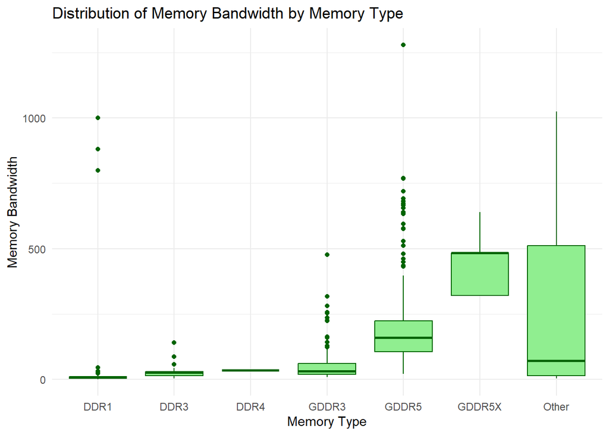

```r
ggplot(processed_data, aes(x = Memory_Type, y = Memory_Bandwidth)) +
  geom_boxplot(fill = "lightgreen", color = "darkgreen", na.rm = TRUE) +
  theme_minimal() +
  labs(title = "Distribution of Memory Bandwidth by Memory Type", x = "Memory Type", y = "Memory Bandwidth")
```

Dựa vào đây ta có thể nhận xét rằng giá trị giá trị của Memory Bandwith có thể biểu diễn cơ bản qua Memory Type nhưng ta sẽ bỏ qua các giá trị ngoại lai (outlier).

```r
replace_na_with_mean_no_outliers <- function(data, group_col, target_col) {
  # Loại bỏ giá trị ngoại lai bằng cách sử dụng IQR
  remove_outliers <- function(x) {
    Q1 <- quantile(x, 0.25, na.rm = TRUE)
    Q3 <- quantile(x, 0.75, na.rm = TRUE)
    IQR_value <- Q3 - Q1
    lower_bound <- Q1 - 1.5 * IQR_value
    upper_bound <- Q3 + 1.5 * IQR_value
    x[x < lower_bound | x > upper_bound] <- NA
    return(x)
  }

  # Áp dụng hàm loại bỏ ngoại lai theo từng nhóm
  data[[target_col]] <- ave(data[[target_col]], data[[group_col]], FUN = function(x) remove_outliers(x))

  # Tính toán giá trị trung bình của từng nhóm sau khi loại bỏ ngoại lai
  group_means <- tapply(data[[target_col]], data[[group_col]], mean, na.rm = TRUE)

  # Thay thế các giá trị NA trong target_col với giá trị trung bình của từng group
  data[[target_col]] <- mapply(function(x, group) {
    if (is.na(x)) {
      return(round(group_means[group], digits = 0))
    } else {
      return(x)
    }
  }, data[[target_col]], data[[group_col]])

  return(data)
}

# Áp dụng hàm để thay thế NA trong Memory_Bus và bỏ qua ngoại lai
processed_data <- replace_na_with_mean_no_outliers(processed_data, "Memory_Type", "Memory_Bandwidth")

# Kiểm tra kết quả
show_na_result()
```

Số lượng và tỉ lệ dữ liệu khuyết ở các biến

|  | NA_Count | NA_Percentage |
| --- | --- | --- |
| Process | 463 | 14 |
| Memory | 420 | 12 |
| Memory_Speed | 0 | 0 |
| Memory_Bandwidth | 0 | 0 |
| Memory_Type | 0 | 0 |
| Memory_Bus | 0 | 0 |
| L2_Cache | 0 | 0 |
| Architecture | 0 | 0 |
| Dedicated | 0 | 0 |
| Manufacturer | 0 | 0 |

*2.3.4. Xử lý biến Memory*

Thay vì xử lý trên các biến khác thay thế bằng giá trị trung bình, ở biến Memory ta nhận thấy các giá trị memory tuân theo một số con số nhất định 128, 256, 512, … Vì thế ở biến Memory ta sẽ thay thế bằng giá trị xuất hiện nhiều nhất ở Memory_Type tương ứng. Nhưng điều đặc biệt ở đây là toàn bộ nhóm Memory_Type là DDR4 đều không có dữ liệu Memory nên ta sẽ không thể tính toán Memory thông qua Memory_Type như chiến lược trên được. Tuy nhiên ta nhận thấy toàn bộ nhóm này đều có Memory_Bandwidth là 34.1 vì thế ta sẽ sử dụng giá trị mode của Memory_Bandwidth = 34.1 ứng với cột Memory để thay thế.

```r
  calculate_mode <- function(x) {
    x <- na.omit(x)  # Bỏ qua NA
    if (length(x) == 0) return(NA)
    unique_x <- unique(x)
    freq <- table(x)
    mode_value <- unique_x[which.max(freq)]
    return(mode_value)
  }

replace_na_with_mode_by_group <- function(data, target_col, group_col) {


  group_modes <- tapply(data[[target_col]], data[[group_col]], calculate_mode)

  data[[target_col]] <- mapply(function(memory, type) {
    if (is.na(memory)) {
      return(group_modes[[type]])
    } else {
      return(memory)
    }
  }, data[[target_col]], data[[group_col]])

  return(data)
}

processed_data <- replace_na_with_mode_by_group(processed_data, "Memory", "Memory_Type")


replace_na_with_mode_for_specific_type <- function(data, target_col, group_col, group_value) {
  subset_data <- data[data[[group_col]] == group_value, target_col]

  mode_value <- calculate_mode(subset_data)

  data[[target_col]] <- ifelse(
    is.na(data[[target_col]]) & data[[group_col]] == group_value,
    mode_value,
    data[[target_col]]
  )

  return(data)
}

processed_data <- replace_na_with_mode_for_specific_type(processed_data, "Memory", "Memory_Bandwidth", 34.1)



# Kiểm tra kết quả
show_na_result()
```

Số lượng và tỉ lệ dữ liệu khuyết ở các biến

|  | NA_Count | NA_Percentage |
| --- | --- | --- |
| Process | 463 | 14 |
| Memory_Speed | 0 | 0 |
| Memory | 0 | 0 |
| Memory_Bandwidth | 0 | 0 |
| Memory_Type | 0 | 0 |
| Memory_Bus | 0 | 0 |
| L2_Cache | 0 | 0 |
| Architecture | 0 | 0 |
| Dedicated | 0 | 0 |
| Manufacturer | 0 | 0 |

*2.3.5. Xử lý biến Process*

Tương tự như xử lý biến Memory, ta nhận thấy Process và Architecture có một mối liên hệ nào đó vì thế ta sẽ thay thế giá trị na của Process bằng mode của Architecture tương ứng. Tuy nhiên sẽ có một số giá trị vẫn chưa thể thay thế được tương tự như Memory ta cũng phải một thêm một giá trị khác nữa để có thể thay thế giá trị na. Ở đây ta cũng sử dụng biến Memory_bandwidth bởi khi nhìn sang cột Memory_bandwidth ta sẽ thấy một số giá trị nhất định: 6.4, 7.0, 8.5, 10.7, 12.8, 17.1.

```r
processed_data <- replace_na_with_mode_by_group(processed_data, "Process", "Architecture")

bandwidth_values <- c(6.4, 7.0, 8.5, 10.7, 12.8, 17.1)

for (value in bandwidth_values) {
  processed_data <- replace_na_with_mode_for_specific_type(processed_data, "Process", "Memory_Bandwidth", value)
}


show_na_result()
```

Số lượng và tỉ lệ dữ liệu khuyết ở các biến

|  | NA_Count | NA_Percentage |
| --- | --- | --- |
| Memory_Speed | 0 | 0 |
| Memory | 0 | 0 |
| Memory_Bandwidth | 0 | 0 |
| Memory_Type | 0 | 0 |
| Memory_Bus | 0 | 0 |
| L2_Cache | 0 | 0 |
| Architecture | 0 | 0 |
| Process | 0 | 0 |
| Dedicated | 0 | 0 |
| Manufacturer | 0 | 0 |

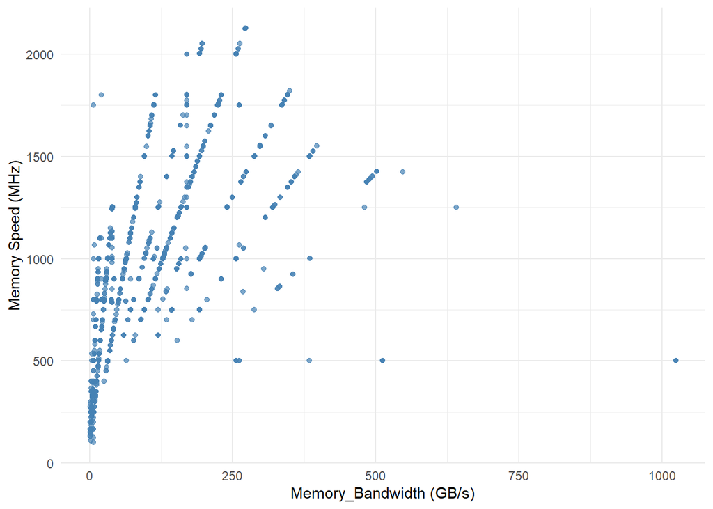

```r
ggplot(processed_data, aes(x = Memory_Bandwidth, y = Memory_Speed)) +
  geom_point(color = "steelblue", alpha = 0.7) +
  labs(
       x = "Memory_Bandwidth (GB/s)",
       y = "Memory Speed (MHz)",
       Caption = "Đồ thị Scatter Plot của Memory Speed theo Memory_Bandwidth") +
  theme_minimal()+
      theme(
        plot.caption = element_text(hjust = 0.5, face = "italic", color = "darkred")
      )
```

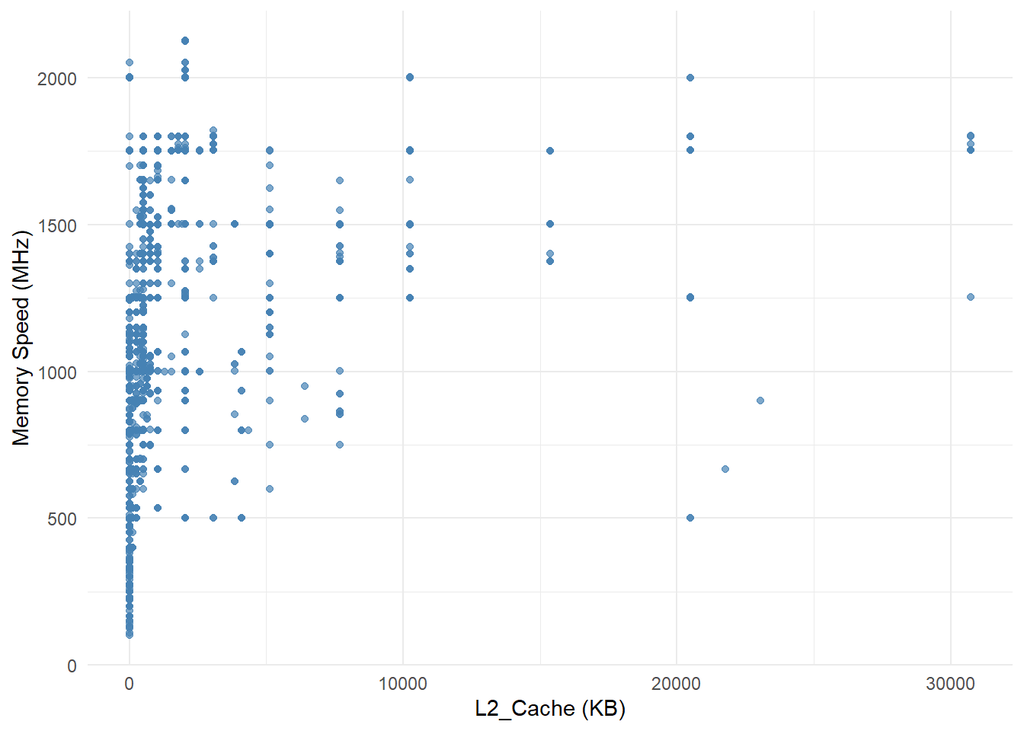

```r
ggplot(processed_data, aes(x = L2_Cache, y = Memory_Speed)) +
  geom_point(color = "steelblue", alpha = 0.7) +
  labs(
       x = "L2_Cache (KB)",
       y = "Memory Speed (MHz)",
       Caption = "Đồ thị Scatter Plot của Memory Speed theo L2_Cache") +
  theme_minimal()+
      theme(
        plot.caption = element_text(hjust = 0.5, face = "italic", color = "darkred")
      )
```

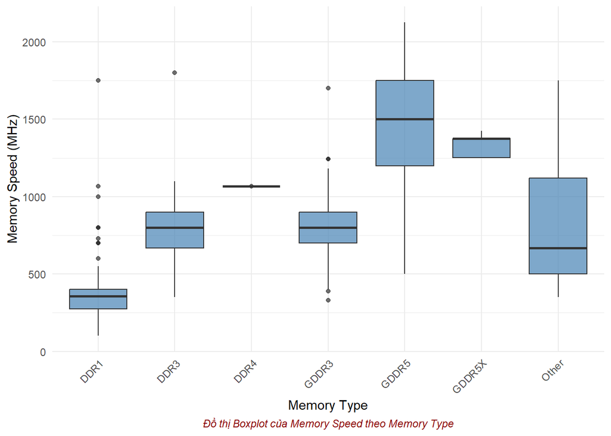

```r
ggplot(processed_data, aes(x = Memory_Type, y = Memory_Speed)) +
  geom_boxplot(fill = "steelblue", alpha = 0.7) +
  labs(
       x = "Memory Type",
       y = "Memory Speed (MHz)",
       caption = "Đồ thị Boxplot của Memory Speed theo Memory Type") +
  theme_minimal() +
  theme(axis.text.x = element_text(angle = 45, hjust = 1), plot.caption = element_text(hjust = 0.5, face = "italic", color = "darkred")
        )
```

**3.THỐNG KÊ SUY DIỄN** Q-Q plot:

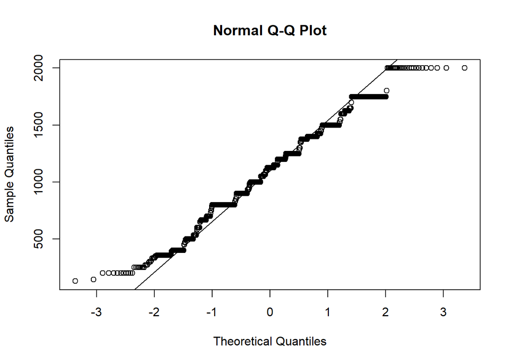

```r
AMD_data <- subset(processed_data ,processed_data$Manufacturer == "AMD")
qqnorm(AMD_data$Memory_Speed)
qqline(AMD_data$Memory_Speed)
```

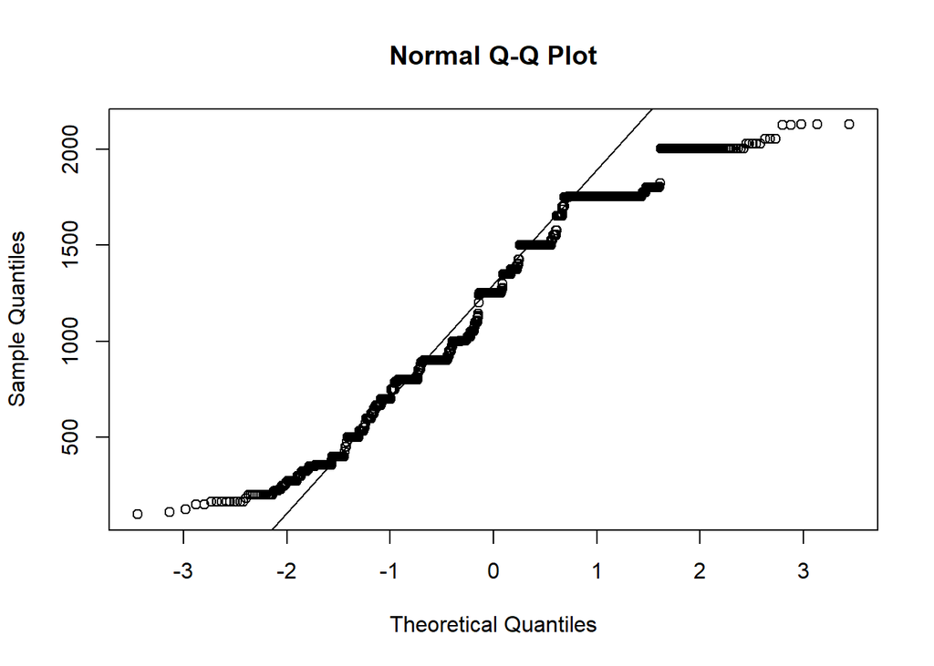

```r
Nvidia_data <- subset(processed_data ,processed_data$Manufacturer == "Nvidia")
qqnorm(Nvidia_data$Memory_Speed)
qqline(Nvidia_data$Memory_Speed)
```

```r
shapiro.test(Nvidia_data$Memory_Speed)
```

```
##
##  Shapiro-Wilk normality test
##
## data:  Nvidia_data$Memory_Speed
## W = 0.9573, p-value < 2.2e-16
```

```r
shapiro.test(Nvidia_data$Memory_Speed)
```

```
##
##  Shapiro-Wilk normality test
##
## data:  Nvidia_data$Memory_Speed
## W = 0.9573, p-value < 2.2e-16
```

Tinh đặc trưng mẫu: AMD

```r
n<-length(AMD_data$Memory_Speed)
xtb<-mean(AMD_data$Memory_Speed)
s<-sd(AMD_data$Memory_Speed)

z_critical <- qnorm(p=1-0.05/2,lower.tail=TRUE)
Epsilon <- qnorm(p=1-0.05/2)*s/sqrt(n)
Left_CI <- xtb-Epsilon
Right_CI <- xtb+Epsilon
data.frame(n,xtb,s,z_critical,Epsilon,Left_CI,Right_CI)
```

```
##      n      xtb        s z_critical  Epsilon  Left_CI Right_CI
## 1 1317 1101.692 391.0011   1.959964 21.11705 1080.575  1122.81
```

Nvidia

```r
n<-length(Nvidia_data$Memory_Speed)
xtb<-mean(Nvidia_data$Memory_Speed)
s<-sd(Nvidia_data$Memory_Speed)

z_critical <- qnorm(p=1-0.05/2,lower.tail=TRUE)
Epsilon <- qnorm(p=1-0.05/2)*s/sqrt(n)
Left_CI <- xtb-Epsilon
Right_CI <- xtb+Epsilon
data.frame(n,xtb,s,z_critical,Epsilon,Left_CI,Right_CI)
```

```
##      n      xtb        s z_critical  Epsilon  Left_CI Right_CI
## 1 1743 1219.555 480.6176   1.959964 22.56312 1196.992 1242.118
```

Kiểm định 2 mẫu:

```r
var.test(AMD_data$Memory_Speed, Nvidia_data$Memory_Speed,alternative="greater")
```

```
##
##  F test to compare two variances
##
## data:  AMD_data$Memory_Speed and Nvidia_data$Memory_Speed
## F = 0.66185, num df = 1316, denom df = 1742, p-value = 1
## alternative hypothesis: true ratio of variances is greater than 1
## 95 percent confidence interval:
##  0.6080988       Inf
## sample estimates:
## ratio of variances
##          0.6618454
```

```r
t.test(AMD_data$Memory_Speed, Nvidia_data$Memory_Speed,
var.equal=T)
```

```
##
##  Two Sample t-test
##
## data:  AMD_data$Memory_Speed and Nvidia_data$Memory_Speed
## t = -7.2662, df = 3058, p-value = 4.671e-13
## alternative hypothesis: true difference in means is not equal to 0
## 95 percent confidence interval:
##  -149.66740  -86.05836
## sample estimates:
## mean of x mean of y
##  1101.692  1219.555
```

```r
one_linear_model <- lm(Memory_Speed ~ Process, data = processed_data)

summary(one_linear_model)
```

```
##
## Call:
## lm(formula = Memory_Speed ~ Process, data = processed_data)
##
## Residuals:
##      Min       1Q   Median       3Q      Max
## -1085.77  -259.93    -9.93   242.07  1489.82
##
## Coefficients:
##              Estimate Std. Error t value Pr(>|t|)
## (Intercept) 1548.1002    10.6347  145.57   <2e-16 ***
## Process      -10.2917     0.2269  -45.37   <2e-16 ***
## ---
## Signif. codes:  0 '***' 0.001 '**' 0.01 '*' 0.05 '.' 0.1 ' ' 1
##
## Residual standard error: 360 on 3404 degrees of freedom
## Multiple R-squared:  0.3768, Adjusted R-squared:  0.3766
## F-statistic:  2058 on 1 and 3404 DF,  p-value: < 2.2e-16
```

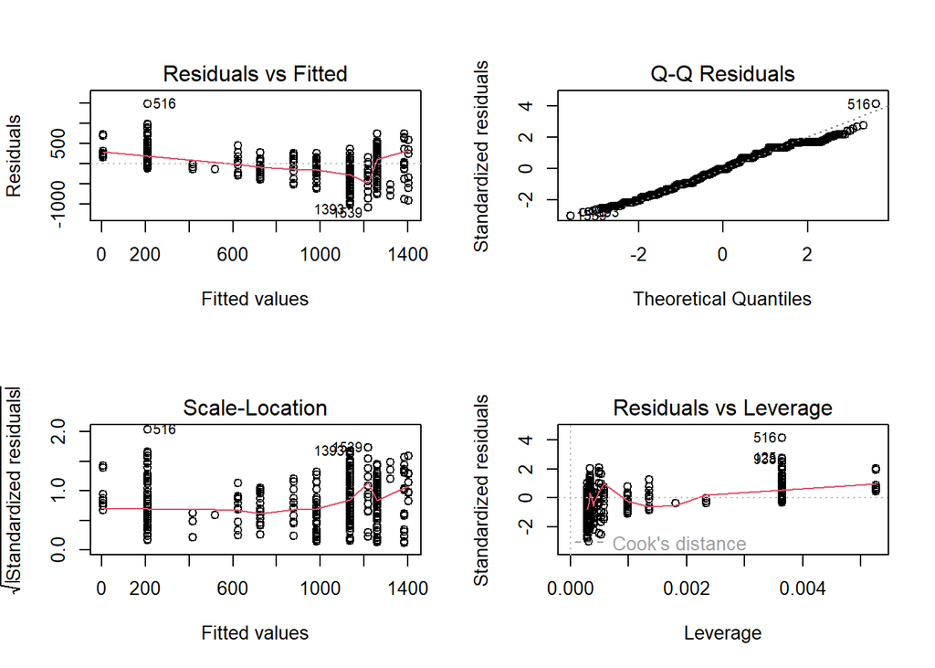

```r
par(mfrow = c(2, 2))
plot(one_linear_model)
```

```r
multiple_linear_model <- lm(Memory_Speed ~ Memory + Memory_Bandwidth + Memory_Type + Memory_Bus + L2_Cache + Architecture + Process + Dedicated + Manufacturer, data = processed_data)

summary(multiple_linear_model)
```

```
##
## Call:
## lm(formula = Memory_Speed ~ Memory + Memory_Bandwidth + Memory_Type +
##     Memory_Bus + L2_Cache + Architecture + Process + Dedicated +
##     Manufacturer, data = processed_data)
##
## Residuals:
##      Min       1Q   Median       3Q      Max
## -1036.42   -95.16    -0.76    99.18  1237.80
##
## Coefficients:
##                         Estimate Std. Error t value Pr(>|t|)
## (Intercept)            5.325e+02  5.716e+01   9.316  < 2e-16 ***
## Memory                 9.451e-03  1.749e-03   5.404 6.96e-08 ***
## Memory_Bandwidth       1.384e+00  5.523e-02  25.053  < 2e-16 ***
## Memory_TypeDDR3        2.684e+02  1.909e+01  14.056  < 2e-16 ***
## Memory_TypeDDR4        3.973e+02  7.979e+01   4.980 6.69e-07 ***
## Memory_TypeGDDR3       3.444e+02  1.659e+01  20.763  < 2e-16 ***
## Memory_TypeGDDR5       4.874e+02  2.047e+01  23.816  < 2e-16 ***
## Memory_TypeGDDR5X     -4.509e+02  3.508e+01 -12.854  < 2e-16 ***
## Memory_TypeOther       2.047e+02  3.494e+01   5.857 5.17e-09 ***
## Memory_Bus            -3.411e-01  1.591e-02 -21.437  < 2e-16 ***
## L2_Cache              -3.458e-03  1.199e-03  -2.883 0.003962 **
## ArchitectureBroadwell  1.727e+02  4.609e+01   3.748 0.000181 ***
## ArchitectureClarkdale  2.616e+01  5.881e+01   0.445 0.656473
## ArchitectureEvergreen  2.139e+01  5.290e+01   0.404 0.685904
## ArchitectureFermi     -9.446e+01  6.244e+01  -1.513 0.130413
## ArchitectureG         -1.070e+01  6.224e+01  -0.172 0.863562
## ArchitectureG84M       2.977e+01  8.094e+01   0.368 0.713059
## ArchitectureG92        5.509e+01  7.613e+01   0.724 0.469319
## ArchitectureGCN        2.497e+02  4.870e+01   5.127 3.11e-07 ***
## ArchitectureHaswell    1.202e+02  4.842e+01   2.483 0.013063 *
## ArchitectureIvy        1.022e+02  4.870e+01   2.098 0.035974 *
## ArchitectureKaveri     2.157e+02  6.189e+01   3.484 0.000499 ***
## ArchitectureKepler     2.263e+02  6.314e+01   3.584 0.000343 ***
## ArchitectureM         -3.146e+01  5.733e+01  -0.549 0.583219
## ArchitectureMaxwell    4.210e+02  6.348e+01   6.631 3.86e-11 ***
## ArchitectureN          2.352e+01  6.435e+01   0.366 0.714750
## ArchitectureOther      3.729e+01  4.352e+01   0.857 0.391541
## ArchitecturePascal     6.257e+02  6.536e+01   9.574  < 2e-16 ***
## ArchitectureR          1.731e+02  5.002e+01   3.462 0.000544 ***
## ArchitectureR700       8.958e+01  5.555e+01   1.612 0.106950
## ArchitectureRV620      1.185e+02  6.745e+01   1.756 0.079118 .
## ArchitectureRV670      1.149e+02  7.151e+01   1.606 0.108336
## ArchitectureRV770     -5.934e+01  6.985e+01  -0.849 0.395664
## ArchitectureSandy     -3.050e+00  4.046e+01  -0.075 0.939910
## ArchitectureSkylake    2.235e+02  8.157e+01   2.740 0.006177 **
## ArchitectureTerascale  4.161e+01  4.794e+01   0.868 0.385529
## ArchitectureTesla      9.997e+01  6.412e+01   1.559 0.119046
## Process               -2.527e+00  3.272e-01  -7.725 1.47e-14 ***
## DedicatedYes           6.069e+00  1.900e+01   0.319 0.749388
## ManufacturerATI        3.225e+02  1.906e+01  16.919  < 2e-16 ***
## ManufacturerIntel     -5.431e+01  3.592e+01  -1.512 0.130593
## ManufacturerNvidia     5.878e+01  4.446e+01   1.322 0.186266
## ---
## Signif. codes:  0 '***' 0.001 '**' 0.01 '*' 0.05 '.' 0.1 ' ' 1
##
## Residual standard error: 165.3 on 3364 degrees of freedom
## Multiple R-squared:  0.8701, Adjusted R-squared:  0.8686
## F-statistic: 549.8 on 41 and 3364 DF,  p-value: < 2.2e-16
```

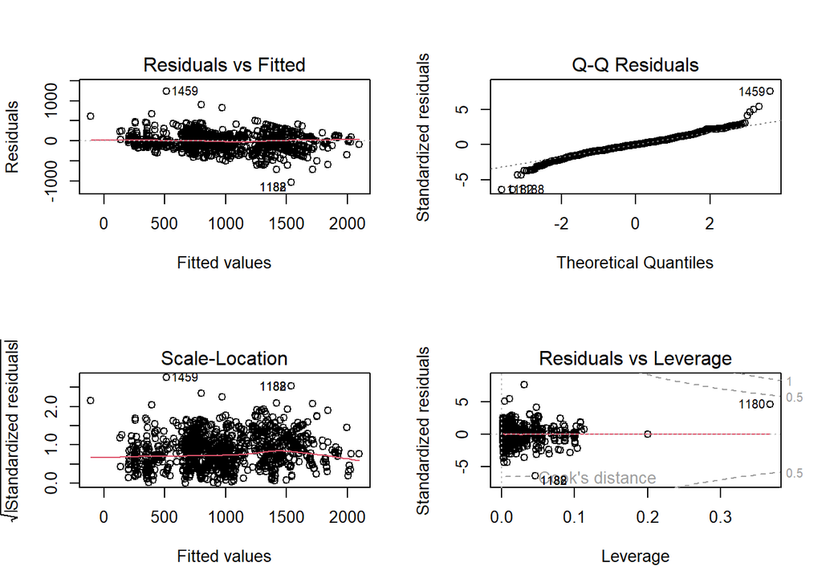

```r
par(mfrow = c(2, 2))
plot(multiple_linear_model)
```